# Team

Jack Novak

3/19/2021

```r
library(readxl)
defense <- read_excel('../slides/cyclonesFootball2020.xlsx', sheet='Defensive')
bio <- read_excel('../slides/cyclonesFootball2020.xlsx', sheet='Biography')
offense <- read_excel('../slides/cyclonesFootball2020.xlsx', sheet='Offensive')
str(defense)
```

```
## tibble [372 × 11] (S3: tbl_df/tbl/data.frame)
##  $ Name             : chr [1:372] "Rose, Mike" "Rose, Mike" "Rose, Mike" "Rose, Mike" ...
##  $ Opponent_Opponent: chr [1:372] "Louisiana" "TCU" "Oklahoma" "Texas Tech" ...
##  $ Tackles_Solo     : chr [1:372] "2" "6" "6" "3" ...
##  $ Tackles_ASST     : chr [1:372] "4" "4" "5" "0" ...
##  $ Tackles_TFL      : chr [1:372] "1.0" "0" "1.5" "1.0" ...
##  $ Tackles_Sack     : chr [1:372] "0" "0" "0.5" "0" ...
##  $ Turnover_FF      : chr [1:372] "0" "0" "0" "0" ...
##  $ Turnover_FR      : chr [1:372] "0" "0" "0" "0" ...
##  $ Turnover_INT     : chr [1:372] "0" "1" "0" "0" ...
##  $ Pass_QBH         : chr [1:372] "0" "0" "1" "0" ...
##  $ Pass_PB          : chr [1:372] "0" "0" "0" "0" ...
```

**Part One**

#1 The player names and opponent names are factors.

```r
library(dplyr)
library(tidyverse)
bio <- bio %>%
  mutate(Name=as.factor(Name))
defense <- defense %>%
  mutate(Name=as.factor(Name), Opponent_Opponent=as.factor(Opponent_Opponent))
offense <- offense %>%
  mutate(Name=as.factor(Name), Opponent_Opponent=as.factor(Opponent_Opponent))
```

#2 All offensive and defensive statistics are numerical. The Weight column in biography is also numeric. (Optional: Read ?across and learn to mutate multiple columns simultaneously using the across function in dplyr)

```r
bio <- bio %>%
  na.omit() %>%
  mutate(Weight = as.numeric(Weight))
defenseClean <- defense %>%
  mutate(across(Tackles_Solo:Pass_PB, as.numeric))
offenseClean = offense %>%
  replace_na(list(.=0)) %>%
  mutate(across(Receiving_REC:Passing_INT,as.numeric)) %>%
  as.data.frame()
```

#3 Change the Height column in biography into numeric. (Hint: Use a unit that works well)

```r
bioClean <- bio %>%
  separate(Height, into = c("Feet", "Inches"), sep = "-") %>%
  mutate(Feet=as.numeric(Feet),Inches=as.numeric(Inches),Feet=12*Feet, Height_inches = Feet+Inches) %>%
  select(-Feet, -Inches)

str(bioClean)
```

```
## tibble [116 × 7] (S3: tbl_df/tbl/data.frame)
##  $ Name         : Factor w/ 116 levels "Akers, Landen",..: 1 2 3 4 5 6 7 8 9 10 ...
##  $ Position     : chr [1:116] "Wide Receiver" "Tight End" "Wide Receiver" "Defensive Back" ...
##  $ Weight       : num [1:116] 191 240 208 180 195 199 253 261 288 182 ...
##  $ Class        : chr [1:116] "Redshirt Senior" "Redshirt Senior" "Redshirt Freshman" "Freshman" ...
##  $ Hometown     : chr [1:116] "Cedar Rapids, Iowa" "Nixa, Mo." "Seffner, Fla." "Ft. Lauderdale, Fla." ...
##  $ Highschool   : chr [1:116] "Washington" "Nixa" "Armwood" "Cardinal Gibbons" ...
##  $ Height_inches: num [1:116] 72 79 77 72 72 72 75 74 74 74 ...
```

```r
str(offenseClean)
```

```
## 'data.frame':    156 obs. of  12 variables:
##  $ Name             : Factor w/ 16 levels "Akers, Landen",..: 1 1 1 1 1 1 1 1 1 1 ...
##  $ Opponent_Opponent: Factor w/ 11 levels "Baylor","Kansas",..: 4 8 5 10 6 2 1 3 9 11 ...
##  $ Receiving_REC    : num  0 2 1 4 0 6 1 0 1 1 ...
##  $ Receiving_YDS    : num  0 60 35 34 0 76 11 0 10 2 ...
##  $ Receiving_TD     : num  0 0 0 0 0 0 0 0 0 1 ...
##  $ Rushing_ATT      : num  NA NA NA NA NA NA NA NA NA NA ...
##  $ Rushing_YDS      : num  NA NA NA NA NA NA NA NA NA NA ...
##  $ Rushing_TD       : num  NA NA NA NA NA NA NA NA NA NA ...
##  $ Passing_CMP-ATT  : num  NA NA NA NA NA NA NA NA NA NA ...
##  $ Passing_YDS      : num  NA NA NA NA NA NA NA NA NA NA ...
##  $ Passing_TD       : num  NA NA NA NA NA NA NA NA NA NA ...
##  $ Passing_INT      : num  NA NA NA NA NA NA NA NA NA NA ...
```

```r
str(defenseClean)
```

```
## tibble [372 × 11] (S3: tbl_df/tbl/data.frame)
##  $ Name             : Factor w/ 37 levels "Akers, Landen",..: 26 26 26 26 26 26 26 26 26 26 ...
##  $ Opponent_Opponent: Factor w/ 11 levels "Baylor","Kansas",..: 4 8 5 10 6 2 1 3 9 11 ...
##  $ Tackles_Solo     : num [1:372] 2 6 6 3 7 4 7 4 4 2 ...
##  $ Tackles_ASST     : num [1:372] 4 4 5 0 3 1 4 3 9 3 ...
##  $ Tackles_TFL      : num [1:372] 1 0 1.5 1 1 0 1.5 2.5 1.5 0 ...
##  $ Tackles_Sack     : num [1:372] 0 0 0.5 0 0 0 0 1 0 0 ...
##  $ Turnover_FF      : num [1:372] 0 0 0 0 0 0 0 0 0 0 ...
##  $ Turnover_FR      : num [1:372] 0 0 0 0 0 0 0 0 0 0 ...
##  $ Turnover_INT     : num [1:372] 0 1 0 0 1 0 1 1 0 0 ...
##  $ Pass_QBH         : num [1:372] 0 0 1 0 0 0 2 1 0 0 ...
##  $ Pass_PB          : num [1:372] 0 0 0 0 0 1 0 0 1 0 ...
```

**Part 2**

#1 Reformat the offClean data frame into a tidy format using pivot_longer. The type of statistic (Receiving_REC for the number of receivings, Receiving_YDS for receiving yards, etc) is added as a new key column named stat.

```r
LongOff2 <- LongOff<-offenseClean %>%
  pivot_longer(Receiving_REC:Passing_INT, names_to ="stat", values_to = "value")%>%
  na.omit() %>%
  as.data.frame()
head(LongOff)
```

```
##            Name Opponent_Opponent          stat value
## 1 Akers, Landen         Louisiana Receiving_REC     0
## 2 Akers, Landen         Louisiana Receiving_YDS     0
## 3 Akers, Landen         Louisiana  Receiving_TD     0
## 4 Akers, Landen               TCU Receiving_REC     2
## 5 Akers, Landen               TCU Receiving_YDS    60
## 6 Akers, Landen               TCU  Receiving_TD     0
```

#2 Show on the distributions of the offensive statistics. The distribution of each offensive statistic should be shown in a separate facet. Explain the patterns you see.

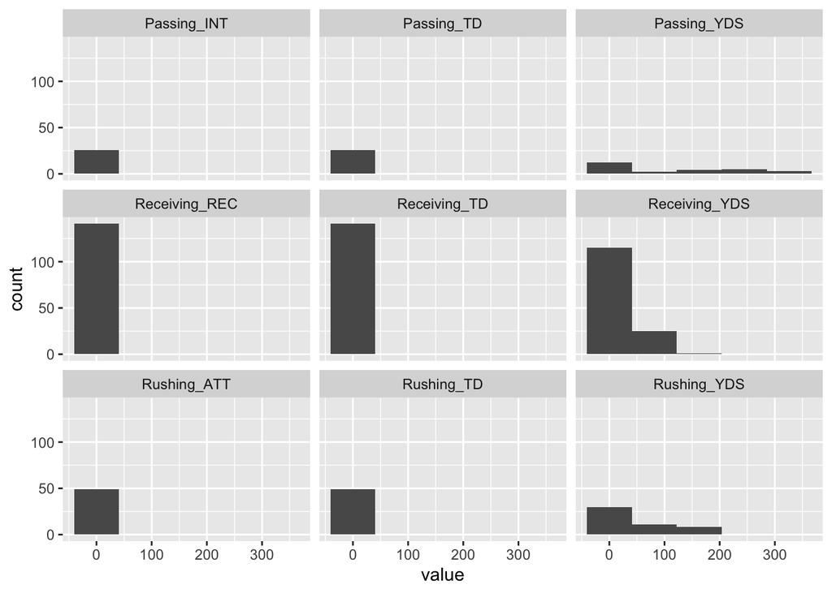

```r
library(ggplot2)
ggplot(LongOff2, aes(x=value))+geom_histogram(bins=5)+facet_wrap(~stat)
```

#3 Did ISU have better offense against Oregon or Oklahoma? Answer this question by creating a scatterplot with the x- and y-axes being the receiving yards of the ISU players against these two opponents. A large number of receiving yards indicates good offense.

[figure not shown]

```r
t<-LongOff2 %>%
  filter(stat=="Receiving_YDS",Opponent_Opponent %in% c("Oregon", "Oklahoma"))%>%
   mutate(row = row_number()) %>%
  pivot_wider(names_from = Opponent_Opponent, values_from = value) %>%
  select(-row)

ggplot(t, aes(x=Oklahoma, y=Oregon))+geom_point()
```

#4 Separate the Hometown column into two columns, namely, the city and the state where the player comes from. Print the first few rows of these two columns. (Hint: look at the sep= argument of separate)

```r
pbr <- bioClean %>%
  separate(Hometown, into = c("City","State"), sep=", ")
head(pbr)
```

```
## # A tibble: 6 x 8
##   Name       Position   Weight Class     City    State Highschool  Height_inches
##   <fct>      <chr>       <dbl> <chr>     <chr>   <chr> <chr>               <dbl>
## 1 Akers, La… Wide Rece…    191 Redshirt… Cedar … Iowa  Washington             72
## 2 Allen, Ch… Tight End     240 Redshirt… Nixa    Mo.   Nixa                   79
## 3 Anderson,… Wide Rece…    208 Redshirt… Seffner Fla.  Armwood                77
## 4 Antoine J… Defensive…    180 Freshman  Ft. La… Fla.  Cardinal G…            72
## 5 Assalley,… Placekick…    195 Redshirt… Naperv… Ill.  Central                72
## 6 Azunna, A… Defensive…    199 Redshirt… Grand … Texas Lake Ridge             72
```

#5 How many players are there from each state?

```r
pbr %>%
  group_by(State) %>%
  summarise(table(State))
```

```
## # A tibble: 21 x 2
##    State     `table(State)`
##  * <chr>     <table>
##  1 Ariz.      4
##  2 Ark.       1
##  3 Australia  1
##  4 Calif.     2
##  5 Fla.      14
##  6 Ga.        3
##  7 Ill.       6
##  8 Iowa      42
##  9 Kan.       4
## 10 Mich       1
## # … with 11 more rows
```

**Part 3**

#1 Find which states do the ISU players (both defensive and offensive) come from. Create an appropriate numerical or graphical summary.

```r
all<-left_join(offenseClean, defenseClean)%>%
  left_join(pbr)%>%
  group_by(State)
  table(all$State)
```

```
##
## Ariz.  Ark.  Fla.  Ill.  Iowa  Kan.   Mo.  Ohio Okla. Texas
##    14    13    25    12    17    24    11    13    23    18
```

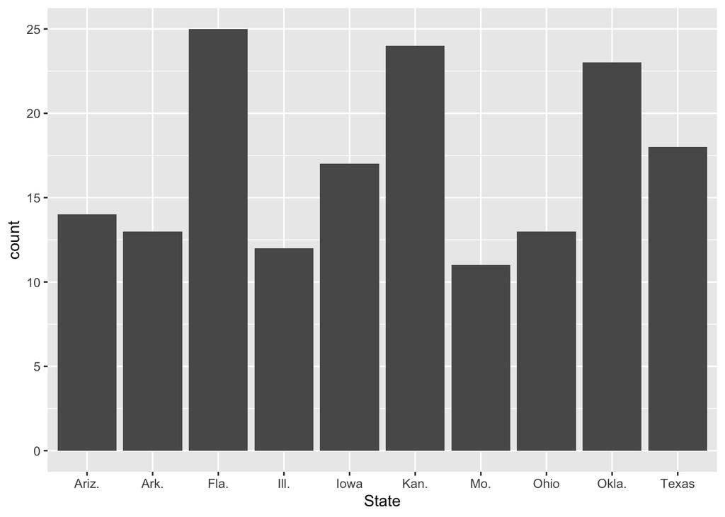

```r
tt <- ggplot(all, aes(State))

tt+geom_bar()
```

#2 How does the performance of quarterback Brock Purdy relate to the performance of the ISU team?

```r
brock <- all %>%
  filter(Name=="Purdy, Brock") %>%
  select(Name,Rushing_YDS, Tackles_Solo, State, Opponent_Opponent)%>%
  summarize(mean=mean(Rushing_YDS, rm.na=TRUE), mean2=mean(Tackles_Solo, rm.na=TRUE))

ISUteam <- all %>%
  filter(Name!="Purdy, Brock")%>%
  select(Name,Rushing_YDS, Tackles_Solo, State, Opponent_Opponent) %>%
  group_by(Name) %>%
  summarize(mean=mean(Rushing_YDS, rm.na=TRUE), mean2=mean(Tackles_Solo, rm.na=TRUE))

brock
```

```
## # A tibble: 1 x 3
##   State  mean  mean2
##   <chr> <dbl>  <dbl>
## 1 Ariz.  29.5 0.0714
```

```r
ISUteam
```

```
## # A tibble: 15 x 3
##    Name                 mean   mean2
##  * <fct>               <dbl>   <dbl>
##  1 Akers, Landen       NA     0.286
##  2 Allen, Chase        NA    NA
##  3 Bitter, Aidan       NA    NA
##  4 Brock, Jirehl        3.83  0.167
##  5 Dean, Easton        NA    NA
##  6 Dekkers, Hunter      4    NA
##  7 Hall, Breece       131    NA
##  8 Hutchinson, Xavier  NA     0.143
##  9 Jackson, Daniel     NA    NA
## 10 Kolar, Charlie      NA    NA
## 11 Milton, Tarique     NA    NA
## 12 Nwangwu, Kene       24.3   0.0714
## 13 Scates, Joe         NA     0.0769
## 14 Shaw Jr., Sean      NA    NA
## 15 Soehner, Dylan      NA     0.0769
```

#3 Which ISU player(s) made the biggest progress over the last year? Compare the player-level statistics (i.e. averages and totals for each player) using both the 2020 and the 2019 data here. Choose for yourself the player statistics to investigate.

```r
defense2019 <- read_excel('../slides/cyclonesFootball2019.xlsx', sheet='Defensive') %>%
    mutate(Name=as.factor(Name), Opponent_Opponent=as.factor(Opponent_Opponent))%>%
   mutate(across(Tackles_Solo:Pass_PB, as.numeric))

bio2019 <- read_excel('../slides/cyclonesFootball2019.xlsx', sheet='Biography')%>%
  separate(Height, into = c("Feet", "Inches"), sep = "-") %>%
  mutate(Feet=as.numeric(Feet),Inches=as.numeric(Inches),Feet=12*Feet, Height_inches = Feet+Inches) %>%
  select(-Feet, -Inches)

offense2019 <- read_excel('../slides/cyclonesFootball2019.xlsx', sheet='Offensive')%>%
  mutate(Name=as.factor(Name), Opponent_Opponent=as.factor(Opponent_Opponent))%>%
  replace_na(list(.=0)) %>%
  mutate(across(Rushing_ATT:Passing_INT,as.numeric)) %>%
  as.data.frame()
all2 <- left_join(defense2019, offense2019) %>%
  left_join(bio2019) %>%
  group_by(Name) %>%
  summarize(mean=mean(Rushing_YDS, rm.na=TRUE), mean2=mean(Tackles_Solo, rm.na=TRUE))
all2
```

```
## # A tibble: 43 x 3
##    Name                 mean  mean2
##  * <chr>               <dbl>  <dbl>
##  1 Akers, Landen       0.615 0.692
##  2 Allen, Chase       NA     0.154
##  3 Azunna, Arnold     NA     1.64
##  4 Bailey, JaQuan     NA     0.5
##  5 Bickham, Justin    NA     1.67
##  6 Downing, Trevor    NA     0.0769
##  7 Eisworth, Greg     NA     3.08
##  8 Gescheidler, Jared NA     0.273
##  9 Grant, Jatairis    NA     0.455
## 10 Greene, Conner     NA     0.0769
## # … with 33 more rows
```

Breece Hall is the most improved for a few reasons: (1) I’m pretty tired and recognize these numerical summaries as objectively terrible, and (2) his average rushing years increased from 74.75 in 2019 to 131 in 2020. Plus, I watched some of the games and I opine that he is the most improved.